# Note-GAM

Weiquan Luo

Updated by 2021-01-21

### Use of this document

This is a study note for Generalized additive model for Non-linear relationship. The original materical is from https://noamross.github.io/gams-in-r-course/.

### Prerequisites

```r
library(mgcv) # gam()
library(dplyr) # data manupulation
```

### Data

```r
x <- seq(0, pi * 2, 0.01)
sin_x <- sin(x)
y <- sin_x + rnorm(n = length(x), mean = 0, sd = sd(sin_x / 2))
dat <- data.frame(x,y)
```

# 1. Introduction

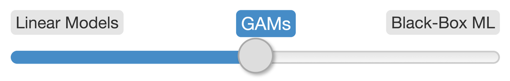

tradeoff-offs in Model Building

Whenever we build statistical models, we face a trade-off between flexibility and interpretability. GAMs offer a middle ground between simple models, such as those we fit with linear regression, and more complex machine learning models like neural networks.

- `machine learning models`, like boosted regression trees or neural networks, can be very good at making predictions of complex relationships. The problem is that they tend to need lots of data, are quite difficult to interpret, and one can rarely make inferences from the model results.
- `Linear models` are easy to interpret and to use for inference: It is easy to understand the meaning of their parameters. However, we often need to model more complex phenomena than can be represented by linear relationships.

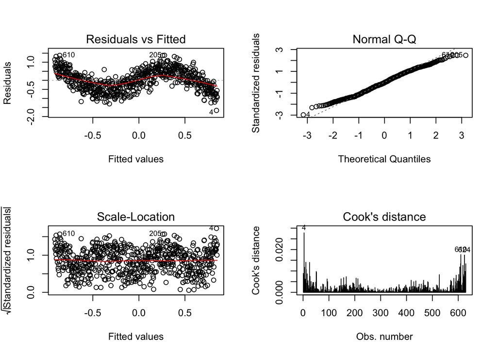

```r
library(stats)
lm_p1 <- lm(y ~ x, data = dat)
par(mfrow= c(2,2))
plot(lm_p1, which=1:4)
```

- `Generalized additive model` offer a middle ground: they can be fit to complex, nonlinear relationships and make good predictions in these cases, but we are still able to do inferential statistics and understand and explain the underlying structure of our models and why they make predictions that they do.

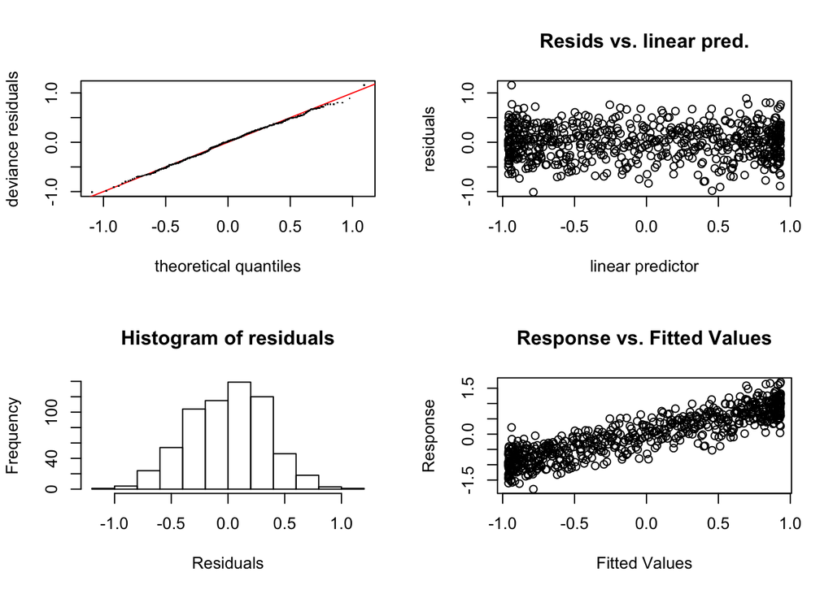

```
##
## Method: REML   Optimizer: outer newton
## full convergence after 7 iterations.
## Gradient range [-7.612461e-05,7.71478e-05]
## (score 242.7588 & scale 0.1197636).
## Hessian positive definite, eigenvalue range [3.682763,313.5367].
## Model rank =  10 / 10
##
## Basis dimension (k) checking results. Low p-value (k-index<1) may
## indicate that k is too low, especially if edf is close to k'.
##
##        k'  edf k-index p-value
## s(x) 9.00 7.74    0.94   0.055 .
## ---
## Signif. codes:  0 '***' 0.001 '**' 0.01 '*' 0.05 '.' 0.1 ' ' 1
```

```r
library(mgcv)
gam_dat <- gam(y ~ s(x), data = dat, method = "REML")
par(mfrow= c(2,2))
gam.check(gam_dat)
```

## 1.1 Trade-off between Likelihood and Wiggliness

The key to a good fit is the trade-off between the `likelihood` and `wiggliness`

- `likelihood`: the measure of how well the GAM captures patterns in the data.
- `wiggliness`: the measure of Its complexity, or how much the curve changes shape

This trade-off is expressed by this simple equation, with $\lambda$, a smoothing parameter,, controlling the balance. This smoothing parameter is optimized when R fits a GAM to data.

$Fit = Likelihood - \lambda \times Wiggliness$

### 1.1.1 Smoonthing Parameter

Smoothing via restricted maximum likelihood

```r
gam_sp1 <- gam(y ~ s(x), data = dat, sp = 0.1)
gam_sp2 <- gam(y ~ s(x, sp = 0.1), data = dat)
# Use the defaults
gam_dat <- gam(y ~ s(x), data = dat, method = "REML")
```

Smooth terms are specified in a gam formula using s, te, ti and t2 terms. Various smooth classes are available, for different modelling tasks, and users can add smooth classes (see user.defined.smooth). What defines a smooth class is the basis used to represent the smooth function and quadratic penalty (or multiple penalties) used to penalize the basis coefficients in order to control the degree of smoothness. Smooth classes are invoked directly by s terms, or as building blocks for tensor product smoothing via te, ti or t2 terms (only smooth classes with single penalties can be used in tensor products). The smooths built into the mgcv package are all based one way or another on low rank versions of splines. For the full rank versions see Wahba (1990).

Note that smooths can be used rather flexibly in gam models. In particular the linear predictor of the GAM can depend on (a discrete approximation to) any linear functional of a smooth term, using by variables and the ‘summation convention’ explained in linear.functional.terms.

The single penalty built in smooth classes are summarized as follows

Thin plate regression splines bs=“tp”. These are low rank isotropic smoothers of any number of covariates. By isotropic is meant that rotation of the covariate co-ordinate system will not change the result of smoothing. By low rank is meant that they have far fewer coefficients than there are data to smooth. They are reduced rank versions of the thin plate splines and use the thin plate spline penalty. They are the default smooth for s terms because there is a defined sense in which they are the optimal smoother of any given basis dimension/rank (Wood, 2003). Thin plate regression splines do not have ‘knots’ (at least not in any conventional sense): a truncated eigen-decomposition is used to achieve the rank reduction. See tprs for further details.

bs=“ts” is as “tp” but with a modification to the smoothing penalty, so that the null space is also penalized slightly and the whole term can therefore be shrunk to zero.

Duchon splines bs=“ds”. These generalize thin plate splines. In particular, for any given number of covariates they allow lower orders of derivative in the penalty than thin plate splines (and hence a smaller null space). See Duchon.spline for further details.

Cubic regression splines bs=“cr”. These have a cubic spline basis defined by a modest sized set of knots spread evenly through the covariate values. They are penalized by the conventional intergrated square second derivative cubic spline penalty. For details see cubic.regression.spline and e.g. Wood (2006a).

bs=“cs” specifies a shrinkage version of “cr”.

bs=“cc” specifies a cyclic cubic regression splines (see cyclic.cubic.spline). i.e. a penalized cubic regression splines whose ends match, up to second derivative.

Splines on the sphere bs=“sos”. These are two dimensional splines on a sphere. Arguments are latitude and longitude, and they are the analogue of thin plate splines for the sphere. Useful for data sampled over a large portion of the globe, when isotropy is appropriate. See Spherical.Spline for details.

P-splines bs=“ps”. These are P-splines as proposed by Eilers and Marx (1996). They combine a B-spline basis, with a discrete penalty on the basis coefficients, and any sane combination of penalty and basis order is allowed. Although this penalty has no exact interpretation in terms of function shape, in the way that the derivative penalties do, P-splines perform almost as well as conventional splines in many standard applications, and can perform better in particular cases where it is advantageous to mix different orders of basis and penalty.

bs=“cp” gives a cyclic version of a P-spline (see cyclic.p.spline).

Random effects bs=“re”. These are parametric terms penalized by a ridge penalty (i.e. the identity matrix). When such a smooth has multiple arguments then it represents the parametric interaction of these arguments, with the coefficients penalized by a ridge penalty. The ridge penalty is equivalent to an assumption that the coefficients are i.i.d. normal random effects. See smooth.construct.re.smooth.spec.

Markov Random Fields bs=“mrf”. These are popular when space is split up into discrete contiguous geographic units (districts of a town, for example). In this case a simple smoothing penalty is constructed based on the neighbourhood structure of the geographic units. See mrf for details and an example.

Gaussian process smooths bs=“gp”. Gaussian process models with a variety of simple correlation functions can be represented as smooths. See gp.smooth for details.

Soap film smooths bs=“so” (actually not single penaltied, but bs=“sw” and bs=“sf” allows splitting into single penalty components for use in tensor product smoothing). These are finite area smoothers designed to smooth within complicated geographical boundaries, where the boundary matters (e.g. you do not want to smooth across boundary features). See soap for details.

Broadly speaking the default penalized thin plate regression splines tend to give the best MSE performance, but they are slower to set up than the other bases. The knot based penalized cubic regression splines (with derivative based penalties) usually come next in MSE performance, with the P-splines doing just a little worse. However the P-splines are useful in non-standard situations.

All the preceding classes (and any user defined smooths with single penalties) may be used as marginal bases for tensor product smooths specified via te, ti or t2 terms. Tensor product smooths are smooth functions of several variables where the basis is built up from tensor products of bases for smooths of fewer (usually one) variable(s) (marginal bases). The multiple penalties for these smooths are produced automatically from the penalties of the marginal smooths. Wood (2006b) and Wood, Scheipl and Faraway (2012), give the general recipe for these constructions.

te te smooths have one penalty per marginal basis, each of which is interpretable in a similar way to the marginal penalty from which it is derived. See Wood (2006b).

ti ti smooths exclude the basis functions associated with the ‘main effects’ of the marginal smooths, plus interactions other than the highest order specified. These provide a stable an interpretable way of specifying models with main effects and interactions. For example if we are interested in linear predicto f1(x) + f2(z) + f3(x,z), we might use model formula y~s(x)+s(z)+ti(x,z) or y~ti(x)+ti(z)+ti(x,z). A similar construction involving te terms instead will be much less statsitically stable.

t2 t2 uses an alternative tensor product construction that results in more penalties each having a simple non-overlapping structure allowing use with the gamm4 package. It is a natural generalization of the SS-ANOVA construction, but the penalties are a little harder to interpret. See Wood, Scheipl and Faraway (2012/13).

Tensor product smooths often perform better than isotropic smooths when the covariates of a smooth are not naturally on the same scale, so that their relative scaling is arbitrary. For example, if smoothing with repect to time and distance, an isotropic smoother will give very different results if the units are cm and minutes compared to if the units are metres and seconds: a tensor product smooth will give the same answer in both cases (see te for an example of this). Note that te terms are knot based, and the thin plate splines seem to offer no advantage over cubic or P-splines as marginal bases.

Some further specialist smoothers that are not suitable for use in tensor products are also available.

Adaptive smoothers bs=“ad” Univariate and bivariate adaptive smooths are available (see adaptive.smooth). These are appropriate when the degree of smoothing should itself vary with the covariates to be smoothed, and the data contain sufficient information to be able to estimate the appropriate variation. Because this flexibility is achieved by splitting the penalty into several ‘basis penalties’ these terms are not suitable as components of tensor product smooths, and are not supported by gamm.

Factor smooth interactions bs=“fs” Smooth factor interactions are often produced using by variables (see gam.models), but a special smoother class (see factor.smooth.interaction) is available for the case in which a smooth is required at each of a large number of factor levels (for example a smooth for each patient in a study), and each smooth should have the same smoothing parameter. The “fs” smoothers are set up to be efficient when used with gamm, and have penalties on each null sapce component (i.e. they are fully ‘random effects’).

### 1.1.2 Basis Function

```r
gam_bf1 <- gam(y ~ s(x, k = 3), data = dat, method = "REML")
gam_bf2 <- gam(y ~ s(x, k = 10), data = dat, method = "REML")
# Use the defaults
gam_dat <- gam(y ~ s(x), data = dat, method = "REML")
coef(gam_dat)
```

```
## (Intercept)      s(x).1      s(x).2      s(x).3      s(x).4      s(x).5
## -0.03120092 -2.19497267  0.25259190 -0.02272388 -0.10277299  0.11583963
##      s(x).6      s(x).7      s(x).8      s(x).9
##  0.18207848  0.04708995  0.21742419  1.51858368
```

### 1.1.4 Link Function

# 2. Multivariate GAMS

## 2.1 Interaction

### 2.1.1 Factor-smooth

### 2.1.2 Tensor-smooth

## 2.2 Spatial GAMs